# PCA en R para Minería de Datos: explicación, visualización y predicción

Notebook all PCA

Curso Minería de Datos - Alex Di Genova

2026

# 1 Objetivos

Este RMarkdown desarrolla un análisis profundo de **PCA** (*Principal Component Analysis*) en R, desde un nivel basico a avanzado.

El objetivo es mostrar PCA como una herramienta para:

1. Explorar datos multivariados.
2. Reducir dimensionalidad.
3. Visualizar patrones complejos.
4. Interpretar componentes principales usando *loadings*.
5. Correlacionar componentes con metadata.
6. Detectar outliers multivariados.
7. Usar PCA como insumo para regresión lineal.
8. Usar PCA como insumo para regresión logística.
9. Trabajar con variables numéricas, categóricas y mixtas.
10. Comparar PCA con modelos usando variables originales.

Trabajaremos principalmente con:

- `AmesHousing`: precios de casas.
- `iris`: clasificación simple y visual.
- `BreastCancer`: clasificación binaria.
- `nycflights13::flights`: variables operacionales de vuelos.
- Datos simulados para colinealidad y batch effects.

# 2 Instalación y carga de paquetes

Ejecuta esta celda una vez si no tienes los paquetes instalados.

```r
packages <- c(
  "tidyverse",
  "AmesHousing",
  "FactoMineR",
  "factoextra",
  "broom",
  "nycflights13",
  "ISLR2",
  "janitor",
  "patchwork",
  "glmnet",
  "MASS",
  "pROC",
  "mlbench",
  "elasticnet"
)

installed <- rownames(installed.packages())
to_install <- setdiff(packages, installed)

if (length(to_install) > 0) {
  install.packages(
    to_install,
    repos = "https://cloud.r-project.org",
    dependencies = c("Depends", "Imports")
  )
}
```

```r
library(tidyverse)
library(AmesHousing)
library(FactoMineR)
library(factoextra)
library(broom)
library(nycflights13)
library(ISLR2)
library(janitor)
library(patchwork)
library(glmnet)
library(MASS)
library(pROC)
library(mlbench)
library(elasticnet)

theme_set(theme_minimal())
```

# 3 1. Fundamento conceptual de PCA

PCA busca transformar un conjunto de variables originales posiblemente correlacionadas en un nuevo conjunto de variables no correlacionadas llamadas **componentes principales**.

Cada componente principal es una combinación lineal de las variables originales:

$$PC_1 = w_1X_1 + w_2X_2 + \cdots + w_pX_p$$

Donde:

- $X_1, X_2, ..., X_p$ son las variables originales.
- $w_1, w_2, ..., w_p$ son los pesos o *loadings*.
- $PC_1$ es el primer componente principal.

## 3.1 Ideas clave

- `PC1` captura la mayor varianza posible.
- `PC2` captura la mayor varianza restante y es ortogonal a `PC1`.
- Los componentes son combinaciones de las variables originales.
- PCA no usa la variable respuesta; es un método no supervisado.
- Los componentes principales pueden usarse luego en modelos supervisados.

## 3.2 ¿Por qué escalar?

PCA depende de la varianza. Si una variable tiene unidades muy grandes, puede dominar el análisis. Por eso, casi siempre usamos:

$$Z = \frac{X - \mu}{\sigma}$$

En R, esto se hace con `scale()` o usando `prcomp(..., scale. = TRUE)`.

# 4 2. Dataset principal: precios de casas con Ames Housing

Usaremos el dataset `AmesHousing`, que contiene información detallada de viviendas vendidas en Ames, Iowa.

Es un dataset apropiado para PCA porque incluye:

- Variables numéricas.
- Variables categóricas.
- Variables ordinales.
- Variables altamente correlacionadas.
- Una variable respuesta continua: `Sale_Price`.

```r
ames_raw <- make_ames()

dim(ames_raw)
```

```
## [1] 2930   81
```

```r
glimpse(ames_raw)
```

```
## Rows: 2,930
## Columns: 81
## $ MS_SubClass        <fct> One_Story_1946_and_Newer_All_Styles, One_Story_1946…
## $ MS_Zoning          <fct> Residential_Low_Density, Residential_High_Density, …
## $ Lot_Frontage       <dbl> 141, 80, 81, 93, 74, 78, 41, 43, 39, 60, 75, 0, 63,…
## $ Lot_Area           <int> 31770, 11622, 14267, 11160, 13830, 9978, 4920, 5005…
## $ Street             <fct> Pave, Pave, Pave, Pave, Pave, Pave, Pave, Pave, Pav…
## $ Alley              <fct> No_Alley_Access, No_Alley_Access, No_Alley_Access, …
## $ Lot_Shape          <fct> Slightly_Irregular, Regular, Slightly_Irregular, Re…
## $ Land_Contour       <fct> Lvl, Lvl, Lvl, Lvl, Lvl, Lvl, Lvl, HLS, Lvl, Lvl, L…
## $ Utilities          <fct> AllPub, AllPub, AllPub, AllPub, AllPub, AllPub, All…
## $ Lot_Config         <fct> Corner, Inside, Corner, Corner, Inside, Inside, Ins…
## $ Land_Slope         <fct> Gtl, Gtl, Gtl, Gtl, Gtl, Gtl, Gtl, Gtl, Gtl, Gtl, G…
## $ Neighborhood       <fct> North_Ames, North_Ames, North_Ames, North_Ames, Gil…
## $ Condition_1        <fct> Norm, Feedr, Norm, Norm, Norm, Norm, Norm, Norm, No…
```

[output cut: 68 more lines]

```r
ames_raw %>%
  dplyr::select(Sale_Price, Gr_Liv_Area, Total_Bsmt_SF, Garage_Area, Year_Built, Overall_Qual) %>%
  summary()
```

```
##    Sale_Price      Gr_Liv_Area   Total_Bsmt_SF   Garage_Area       Year_Built
##  Min.   : 12789   Min.   : 334   Min.   :   0   Min.   :   0.0   Min.   :1872
##  1st Qu.:129500   1st Qu.:1126   1st Qu.: 793   1st Qu.: 320.0   1st Qu.:1954
##  Median :160000   Median :1442   Median : 990   Median : 480.0   Median :1973
##  Mean   :180796   Mean   :1500   Mean   :1051   Mean   : 472.7   Mean   :1971
##  3rd Qu.:213500   3rd Qu.:1743   3rd Qu.:1302   3rd Qu.: 576.0   3rd Qu.:2001
##  Max.   :755000   Max.   :5642   Max.   :6110   Max.   :1488.0   Max.   :2010
##
##         Overall_Qual
##  Average      :825
##  Above_Average:732
##  Good         :602
##  Very_Good    :350
##  Below_Average:226
##  Excellent    :107
##  (Other)      : 88
```

# 5 3. Exploración inicial del precio de casas

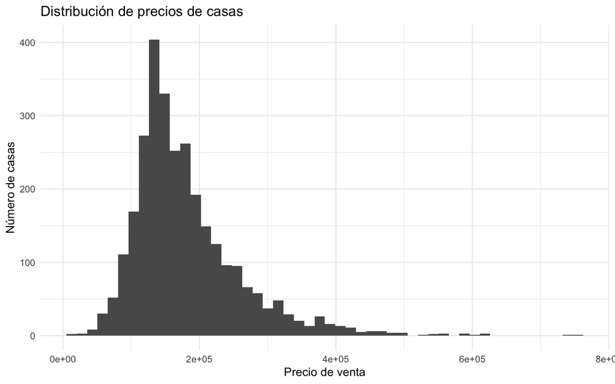

```r
ames_raw %>%
  ggplot(aes(x = Sale_Price)) +
  geom_histogram(bins = 50) +
  labs(
    title = "Distribución de precios de casas",
    x = "Precio de venta",
    y = "Número de casas"
  )
```

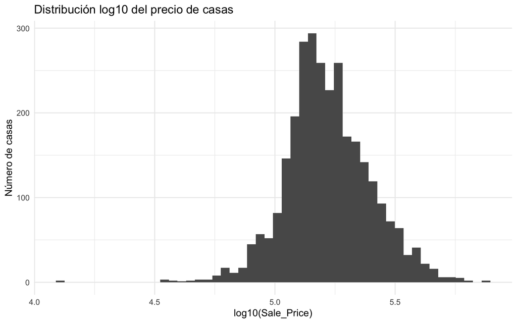

```r
ames_raw %>%
  ggplot(aes(x = log10(Sale_Price))) +
  geom_histogram(bins = 50) +
  labs(
    title = "Distribución log10 del precio de casas",
    x = "log10(Sale_Price)",
    y = "Número de casas"
  )
```

**Interpretación.**  
El precio suele tener una distribución asimétrica a la derecha. En regresión, muchas veces conviene modelar `log10(Sale_Price)` para reducir la influencia de valores extremos.

# 6 4. PCA con variables numéricas

Primero usaremos solo variables numéricas. Esto permite entender el PCA clásico antes de avanzar a variables mixtas.

```r
ames_num <- ames_raw %>%
  dplyr::select(where(is.numeric)) %>%
  dplyr::select(-Sale_Price) %>%
  janitor::clean_names()

# Eliminar columnas sin variación
ames_num <- ames_num %>%
  dplyr::select(where(~ sd(.x, na.rm = TRUE) > 0))

# Imputación simple con mediana
ames_num_imp <- ames_num %>%
  mutate(across(everything(), ~ ifelse(is.na(.x), median(.x, na.rm = TRUE), .x)))

dim(ames_num_imp)
```

```
## [1] 2930   34
```

```r
summary(ames_num_imp[, 1:min(8, ncol(ames_num_imp))])
```

```
##   lot_frontage       lot_area        year_built   year_remod_add
##  Min.   :  0.00   Min.   :  1300   Min.   :1872   Min.   :1950
##  1st Qu.: 43.00   1st Qu.:  7440   1st Qu.:1954   1st Qu.:1965
##  Median : 63.00   Median :  9436   Median :1973   Median :1993
##  Mean   : 57.65   Mean   : 10148   Mean   :1971   Mean   :1984
##  3rd Qu.: 78.00   3rd Qu.: 11555   3rd Qu.:2001   3rd Qu.:2004
##  Max.   :313.00   Max.   :215245   Max.   :2010   Max.   :2010
##   mas_vnr_area    bsmt_fin_sf_1   bsmt_fin_sf_2      bsmt_unf_sf
##  Min.   :   0.0   Min.   :0.000   Min.   :   0.00   Min.   :   0.0
##  1st Qu.:   0.0   1st Qu.:3.000   1st Qu.:   0.00   1st Qu.: 219.0
##  Median :   0.0   Median :3.000   Median :   0.00   Median : 465.5
##  Mean   : 101.1   Mean   :4.177   Mean   :  49.71   Mean   : 559.1
##  3rd Qu.: 162.8   3rd Qu.:7.000   3rd Qu.:   0.00   3rd Qu.: 801.8
##  Max.   :1600.0   Max.   :7.000   Max.   :1526.00   Max.   :2336.0
```

```r
pca_ames <- prcomp(
  ames_num_imp,
  center = TRUE,
  scale. = TRUE
)

summary(pca_ames)
```

```
## Importance of components:
##                           PC1     PC2     PC3     PC4     PC5    PC6     PC7
## Standard deviation     2.4758 1.74045 1.43963 1.40719 1.15436 1.0956 1.08096
## Proportion of Variance 0.1803 0.08909 0.06096 0.05824 0.03919 0.0353 0.03437
## Cumulative Proportion  0.1803 0.26937 0.33033 0.38857 0.42776 0.4631 0.49743
##                            PC8     PC9    PC10    PC11   PC12    PC13    PC14
## Standard deviation     1.05506 1.03109 1.02320 1.00131 0.9964 0.98235 0.95290
## Proportion of Variance 0.03274 0.03127 0.03079 0.02949 0.0292 0.02838 0.02671
## Cumulative Proportion  0.53017 0.56144 0.59223 0.62172 0.6509 0.67930 0.70601
##                          PC15    PC16    PC17    PC18    PC19    PC20    PC21
## Standard deviation     0.9474 0.93704 0.92176 0.90745 0.87416 0.86173 0.83342
## Proportion of Variance 0.0264 0.02582 0.02499 0.02422 0.02248 0.02184 0.02043
## Cumulative Proportion  0.7324 0.75824 0.78323 0.80744 0.82992 0.85176 0.87219
##                           PC22    PC23    PC24    PC25    PC26   PC27   PC28
## Standard deviation     0.78858 0.77431 0.76418 0.74492 0.65539 0.6004 0.5801
## Proportion of Variance 0.01829 0.01763 0.01718 0.01632 0.01263 0.0106 0.0099
## Cumulative Proportion  0.89048 0.90811 0.92529 0.94161 0.95424 0.9648 0.9747
##                           PC29    PC30   PC31    PC32    PC33      PC34
## Standard deviation     0.54433 0.44265 0.3910 0.34608 0.30655 1.246e-15
## Proportion of Variance 0.00871 0.00576 0.0045 0.00352 0.00276 0.000e+00
## Cumulative Proportion  0.98346 0.98922 0.9937 0.99724 1.00000 1.000e+00
```

## 6.1 4.1 Varianza explicada

```r
pca_var <- pca_ames$sdev^2
pca_var_exp <- pca_var / sum(pca_var)
pca_var_cum <- cumsum(pca_var_exp)

pca_summary <- tibble(
  PC = paste0("PC", seq_along(pca_var_exp)),
  varianza_explicada = pca_var_exp,
  varianza_acumulada = pca_var_cum
)

pca_summary %>%
  slice(1:15)
```

```
## # A tibble: 15 × 3
##    PC    varianza_explicada varianza_acumulada
##    <chr>              <dbl>              <dbl>
##  1 PC1               0.180               0.180
##  2 PC2               0.0891              0.269
##  3 PC3               0.0610              0.330
##  4 PC4               0.0582              0.389
##  5 PC5               0.0392              0.428
##  6 PC6               0.0353              0.463
##  7 PC7               0.0344              0.497
##  8 PC8               0.0327              0.530
##  9 PC9               0.0313              0.561
## 10 PC10              0.0308              0.592
## 11 PC11              0.0295              0.622
## 12 PC12              0.0292              0.651
## 13 PC13              0.0284              0.679
## 14 PC14              0.0267              0.706
## 15 PC15              0.0264              0.732
```

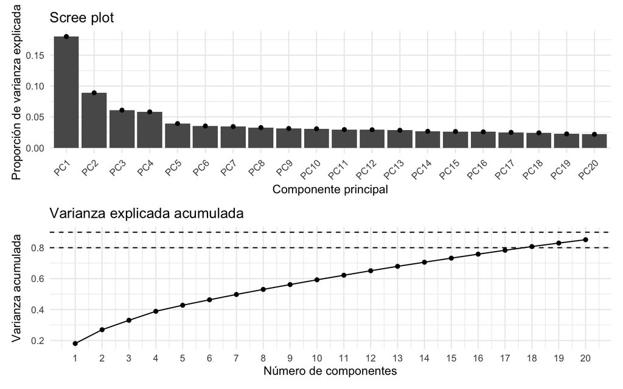

```r
p1 <- pca_summary %>%
  slice(1:20) %>%
  mutate(PC = factor(PC, levels = PC)) %>%
  ggplot(aes(x = PC, y = varianza_explicada)) +
  geom_col() +
  geom_point() +
  labs(
    title = "Scree plot",
    x = "Componente principal",
    y = "Proporción de varianza explicada"
  ) +
  theme(axis.text.x = element_text(angle = 45, hjust = 1))

p2 <- pca_summary %>%
  slice(1:20) %>%
  mutate(n_componentes = row_number()) %>%
  ggplot(aes(x = n_componentes, y = varianza_acumulada)) +
  geom_line() +
  geom_point() +
  geom_hline(yintercept = 0.80, linetype = "dashed") +
  geom_hline(yintercept = 0.90, linetype = "dashed") +
  scale_x_continuous(breaks = 1:20) +
  labs(
    title = "Varianza explicada acumulada",
    x = "Número de componentes",
    y = "Varianza acumulada"
  )

p1 / p2
```

```r
n80 <- which(pca_var_cum >= 0.80)[1]
n90 <- which(pca_var_cum >= 0.90)[1]
n50 <- which(pca_var_cum >= 0.50)[1]

tibble(
  componentes_50 = n50,
  componentes_80 = n80,
  componentes_90 = n90
)
```

```
## # A tibble: 1 × 3
##   componentes_50 componentes_80 componentes_90
##            <int>          <int>          <int>
## 1              8             18             23
```

**Interpretación.**  
Si usamos pocos componentes, perdemos información pero ganamos simplicidad. Si usamos muchos componentes, conservamos información pero reducimos menos la dimensionalidad. Para predicción, conviene elegir el número de componentes con validación cruzada.

# 7 5. Loadings: interpretación de componentes

Los *loadings* indican cuánto contribuye cada variable original a cada componente. Un loading alto positivo o negativo indica que la variable pesa mucho en ese componente.

```r
loadings_ames <- as.data.frame(pca_ames$rotation) %>%
  rownames_to_column("variable")

loadings_ames %>%
  dplyr::select(variable, PC1, PC2, PC3, PC4, PC5) %>%
  arrange(desc(abs(PC1))) %>%
  head(15)
```

```
##           variable        PC1         PC2         PC3          PC4
## 1      gr_liv_area -0.3407391  0.21019323 -0.09107846 -0.136836426
## 2      garage_cars -0.3042947 -0.10300797  0.09430698  0.064517161
## 3      garage_area -0.2970695 -0.12880524  0.02637508  0.059168357
## 4        full_bath -0.2851266  0.12061744  0.09161430  0.090282646
## 5  tot_rms_abv_grd -0.2762017  0.30685664 -0.12023998 -0.104013028
## 6     first_flr_sf -0.2736378 -0.17937891 -0.35697085  0.114578865
## 7    total_bsmt_sf -0.2664979 -0.22191247 -0.26660132  0.162697855
## 8       year_built -0.2415563 -0.21728591  0.32986537  0.127489101
## 9   year_remod_add -0.2221223 -0.10843769  0.30412788  0.131355311
## 10    mas_vnr_area -0.2133806 -0.07666848 -0.02667393 -0.026964000
## 11      fireplaces -0.2016991 -0.05650100 -0.12775506 -0.214061439
## 12   open_porch_sf -0.1622361  0.01645202  0.02036491 -0.003905307
## 13   second_flr_sf -0.1529111  0.40115345  0.23409342 -0.265308377
## 14       half_bath -0.1515871  0.19831574  0.32060046 -0.244163402
```

[output cut: 17 more lines]

```r
plot_loadings <- function(loadings_df, pc = "PC1", top_n = 15) {
  loadings_df %>%
    dplyr::select(variable, all_of(pc)) %>%
    mutate(abs_loading = abs(.data[[pc]])) %>%
    arrange(desc(abs_loading)) %>%
    slice(1:top_n) %>%
    mutate(variable = reorder(variable, .data[[pc]])) %>%
    ggplot(aes(x = variable, y = .data[[pc]])) +
    geom_col() +
    coord_flip() +
    geom_hline(yintercept = 0, linetype = "dashed") +
    labs(
      title = paste("Variables con mayor contribución a", pc),
      x = "Variable",
      y = "Loading"
    )
}
```

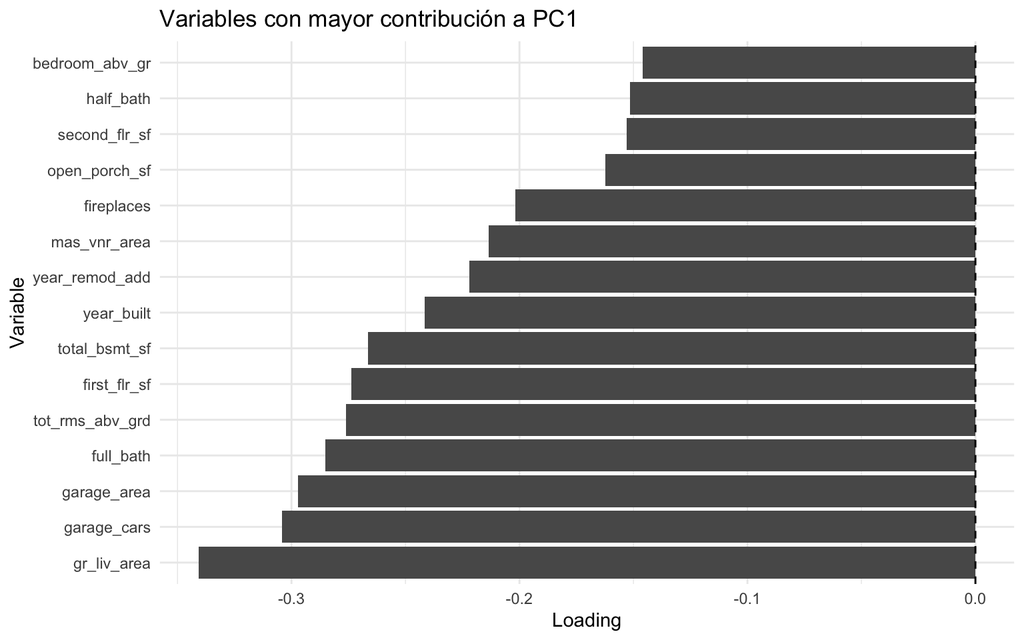

```r
plot_loadings(loadings_ames, "PC1", 15)
```

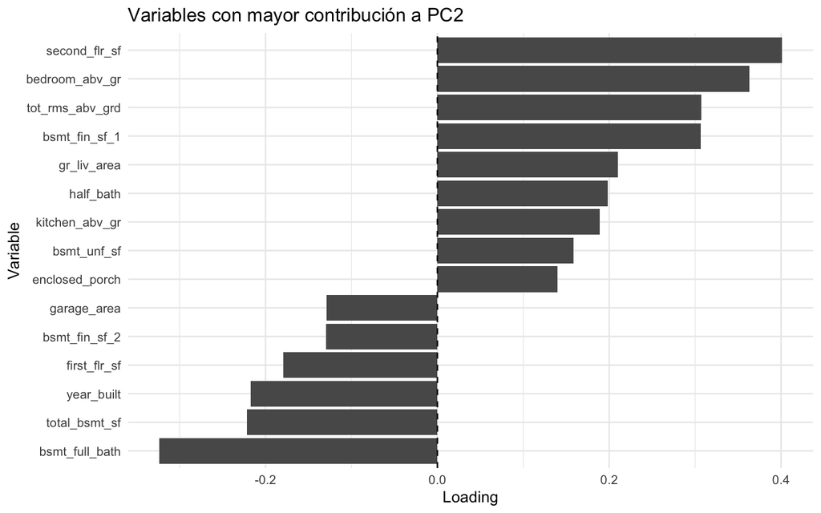

```r
plot_loadings(loadings_ames, "PC2", 15)
```

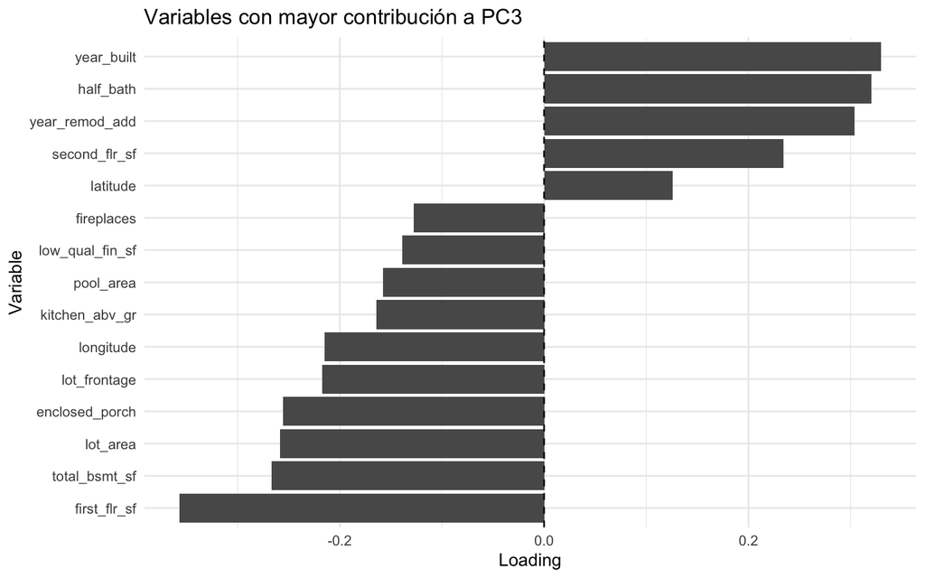

```r
plot_loadings(loadings_ames, "PC3", 15)
```

## 7.1 Cómo interpretar los loadings

Para interpretar un componente:

1. Identifica variables con mayor loading absoluto.
2. Observa signos positivos y negativos.
3. Pregunta si representan tamaño, calidad, edad, ubicación, densidad u otro concepto.
4. Correlaciona el componente con metadata.
5. Visualiza el componente contra variables relevantes.

Ejemplo:

- Si `gr_liv_area`, `garage_area`, `total_bsmt_sf` y `first_flr_sf` pesan fuerte en PC1, probablemente PC1 representa tamaño global de la casa.
- Si `year_built` y `year_remod_add` pesan fuerte, puede representar antigüedad o modernidad.

# 8 6. Scores de PCA y correlación con metadata

Los scores son las coordenadas de cada observación en el espacio PCA.

Ahora correlacionaremos los PCs con metadata:

- `Sale_Price`
- `Overall_Qual`
- `Year_Built`
- `Gr_Liv_Area`
- `Neighborhood`

```r
scores_ames <- as.data.frame(pca_ames$x) %>%
  as_tibble()

ames_metadata <- ames_raw %>%
  transmute(
    Sale_Price = Sale_Price,
    log_Sale_Price = log10(Sale_Price),
    Overall_Qual = as.numeric(Overall_Qual),
    Year_Built = Year_Built,
    Gr_Liv_Area = Gr_Liv_Area,
    Total_Bsmt_SF = Total_Bsmt_SF,
    Garage_Area = Garage_Area,
    Neighborhood = Neighborhood
  )

scores_metadata <- bind_cols(scores_ames, ames_metadata)

scores_metadata %>%
  dplyr::select(PC1:PC5, Sale_Price, log_Sale_Price, Overall_Qual, Year_Built, Gr_Liv_Area) %>%
  cor(use = "pairwise.complete.obs") %>%
  round(2)
```

```
##                  PC1   PC2   PC3   PC4   PC5 Sale_Price log_Sale_Price
## PC1             1.00  0.00  0.00  0.00  0.00      -0.85          -0.87
## PC2             0.00  1.00  0.00  0.00  0.00      -0.16          -0.17
## PC3             0.00  0.00  1.00  0.00  0.00       0.02           0.07
## PC4             0.00  0.00  0.00  1.00  0.00      -0.03          -0.04
## PC5             0.00  0.00  0.00  0.00  1.00      -0.09          -0.06
## Sale_Price     -0.85 -0.16  0.02 -0.03 -0.09       1.00           0.95
## log_Sale_Price -0.87 -0.17  0.07 -0.04 -0.06       0.95           1.00
## Overall_Qual   -0.75 -0.14  0.16  0.11 -0.11       0.80           0.83
## Year_Built     -0.60 -0.38  0.47  0.18  0.08       0.56           0.62
## Gr_Liv_Area    -0.84  0.37 -0.13 -0.19  0.00       0.71           0.70
##                Overall_Qual Year_Built Gr_Liv_Area
## PC1                   -0.75      -0.60       -0.84
## PC2                   -0.14      -0.38        0.37
## PC3                    0.16       0.47       -0.13
## PC4                    0.11       0.18       -0.19
## PC5                   -0.11       0.08        0.00
## Sale_Price             0.80       0.56        0.71
## log_Sale_Price         0.83       0.62        0.70
## Overall_Qual           1.00       0.60        0.57
## Year_Built             0.60       1.00        0.24
## Gr_Liv_Area            0.57       0.24        1.00
```

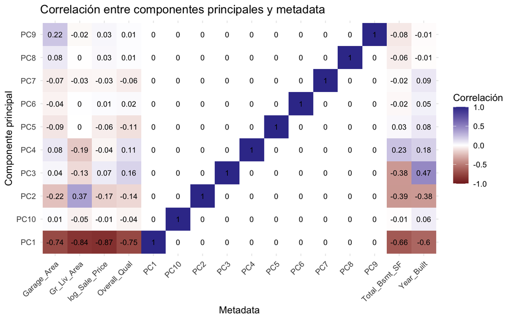

```r
corr_pc_metadata <- scores_metadata %>%
  dplyr::select(PC1:PC10, log_Sale_Price, Overall_Qual, Year_Built, Gr_Liv_Area, Total_Bsmt_SF, Garage_Area) %>%
  cor(use = "pairwise.complete.obs") %>%
  as.data.frame() %>%
  rownames_to_column("variable") %>%
  filter(str_detect(variable, "^PC")) %>%
  pivot_longer(-variable, names_to = "metadata", values_to = "correlation")

corr_pc_metadata %>%
  ggplot(aes(x = metadata, y = variable, fill = correlation)) +
  geom_tile() +
  geom_text(aes(label = round(correlation, 2)), size = 3) +
  scale_fill_gradient2(limits = c(-1, 1)) +
  labs(
    title = "Correlación entre componentes principales y metadata",
    x = "Metadata",
    y = "Componente principal",
    fill = "Correlación"
  ) +
  theme(axis.text.x = element_text(angle = 45, hjust = 1))
```

**Interpretación.**  
La correlación entre PCs y metadata traduce componentes abstractos a conceptos interpretables. Un PC asociado a `Gr_Liv_Area`, `Garage_Area` y `Total_Bsmt_SF` puede representar tamaño de vivienda. Un PC asociado a `Year_Built` puede representar antigüedad o modernidad.

# 9 7. Visualización PCA 2D

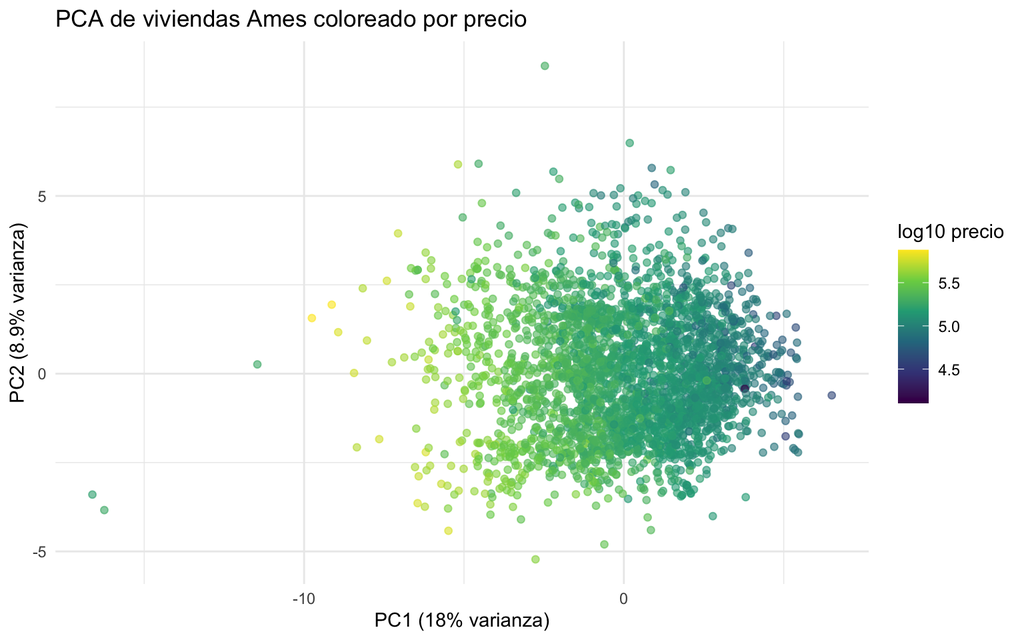

```r
scores_metadata %>%
  ggplot(aes(x = PC1, y = PC2, color = log_Sale_Price)) +
  geom_point(alpha = 0.6, size = 1.6) +
  scale_color_viridis_c() +
  labs(
    title = "PCA de viviendas Ames coloreado por precio",
    x = paste0("PC1 (", round(pca_var_exp[1] * 100, 1), "% varianza)"),
    y = paste0("PC2 (", round(pca_var_exp[2] * 100, 1), "% varianza)"),
    color = "log10 precio"
  )
```

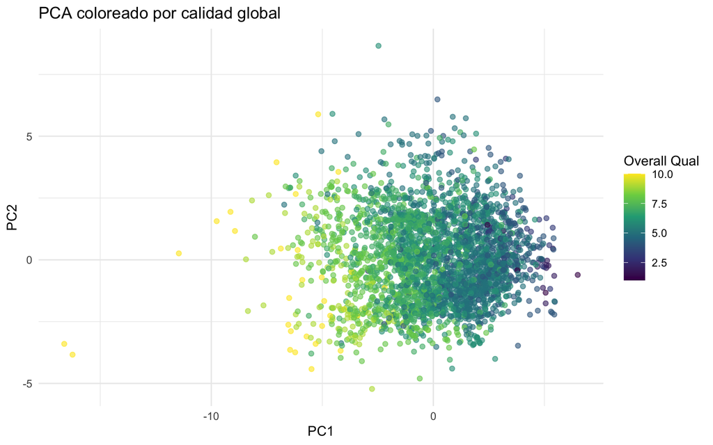

```r
scores_metadata %>%
  ggplot(aes(x = PC1, y = PC2, color = Overall_Qual)) +
  geom_point(alpha = 0.6, size = 1.6) +
  scale_color_viridis_c() +
  labs(
    title = "PCA coloreado por calidad global",
    x = "PC1",
    y = "PC2",
    color = "Overall Qual"
  )
```

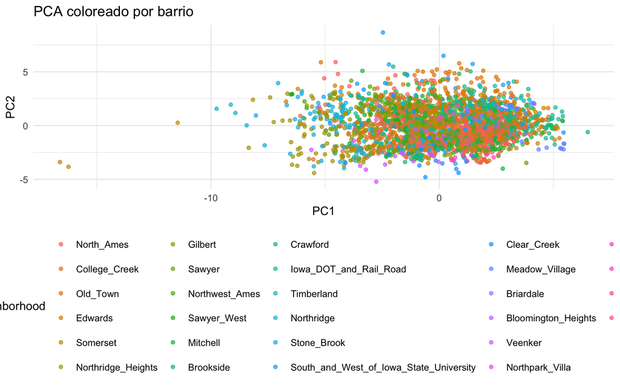

```r
scores_metadata %>%
  ggplot(aes(x = PC1, y = PC2, color = Neighborhood)) +
  geom_point(alpha = 0.7, size = 1.3) +
  labs(
    title = "PCA coloreado por barrio",
    x = "PC1",
    y = "PC2",
    color = "Neighborhood"
  ) +
  theme(legend.position = "bottom")
```

# 10 8. Biplot con `factoextra`

El biplot muestra observaciones y variables en el mismo espacio. Debido a que Ames tiene muchas observaciones, se muestra una submuestra.

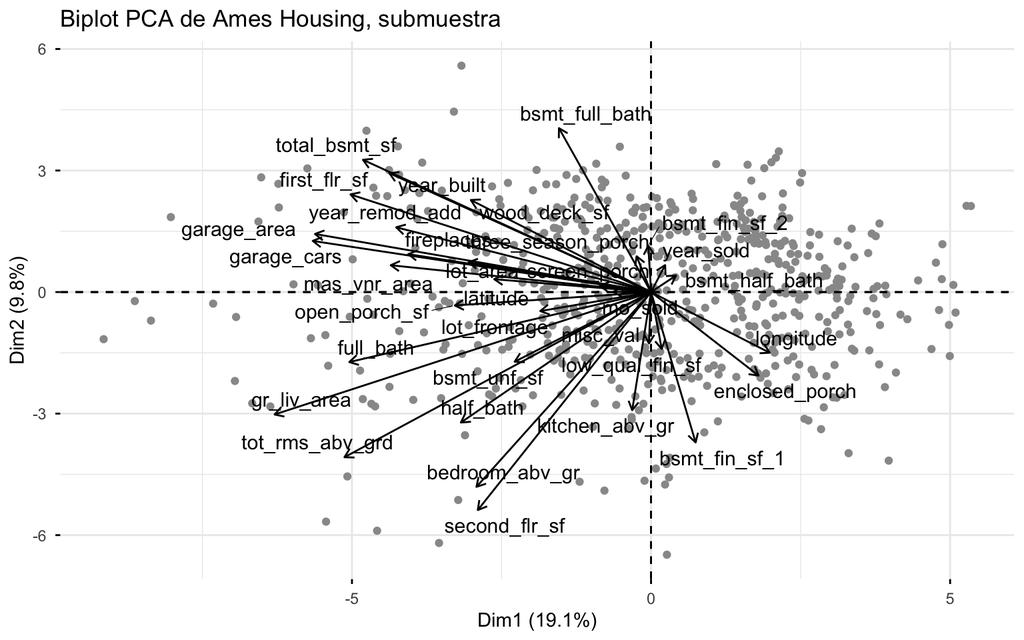

```r
set.seed(123)

sample_ids <- sample(seq_len(nrow(ames_num_imp)), size = 600)

ames_subset=ames_num_imp[sample_ids, ]
zero_var_cols <- names(ames_subset)[
  purrr::map_lgl(ames_subset, ~ sd(.x, na.rm = TRUE) == 0)
]
#we remove all zero sd columns
ames_subset <- ames_subset %>%
  dplyr::select(-all_of(zero_var_cols))

pca_ames_sample <- prcomp(
  ames_subset,
  center = TRUE,
  scale. = TRUE
)

fviz_pca_biplot(
  pca_ames_sample,
  repel = TRUE,
  col.var = "black",
  col.ind = "gray60",
  label = "var",
  #habillage = NULL
) +
  labs(title = "Biplot PCA de Ames Housing, submuestra")
```

# 11 9. Detección de outliers multivariados con PCA

Un outlier multivariado puede no ser extremo en una sola variable, pero sí tener una combinación inusual de variables.

Usaremos dos estrategias:

1. Observaciones extremas en PC1 y PC2.
2. Error de reconstrucción usando pocos componentes.

```r
scores_metadata <- scores_metadata %>%
  mutate(
    dist_pc12 = sqrt(PC1^2 + PC2^2)
  )

scores_metadata %>%
  arrange(desc(dist_pc12)) %>%
  dplyr::select(PC1, PC2, dist_pc12, Sale_Price, Overall_Qual, Gr_Liv_Area, Neighborhood) %>%
  head(10)
```

```
## # A tibble: 10 × 7
##       PC1     PC2 dist_pc12 Sale_Price Overall_Qual Gr_Liv_Area Neighborhood
##     <dbl>   <dbl>     <dbl>      <int>        <dbl>       <int> <fct>
##  1 -16.6  -3.40       17.0      160000           10        5642 Edwards
##  2 -16.2  -3.84       16.7      183850           10        5095 Edwards
##  3 -11.5   0.261      11.5      184750           10        4676 Edwards
##  4  -9.76  1.56        9.88     755000           10        4316 Northridge
##  5  -9.14  1.94        9.34     745000           10        4476 Northridge
##  6  -8.93  1.17        9.01     625000           10        3627 Northridge
##  7  -2.47  8.66        9.00     200000            6        3395 South_and_West_…
##  8  -8.35 -2.07        8.60     500000            9        2696 Northridge_Heig…
##  9  -8.17  2.40        8.51     485000            9        3140 Northridge_Heig…
## 10  -8.44  0.0196      8.44     584500            9        3500 Northridge
```

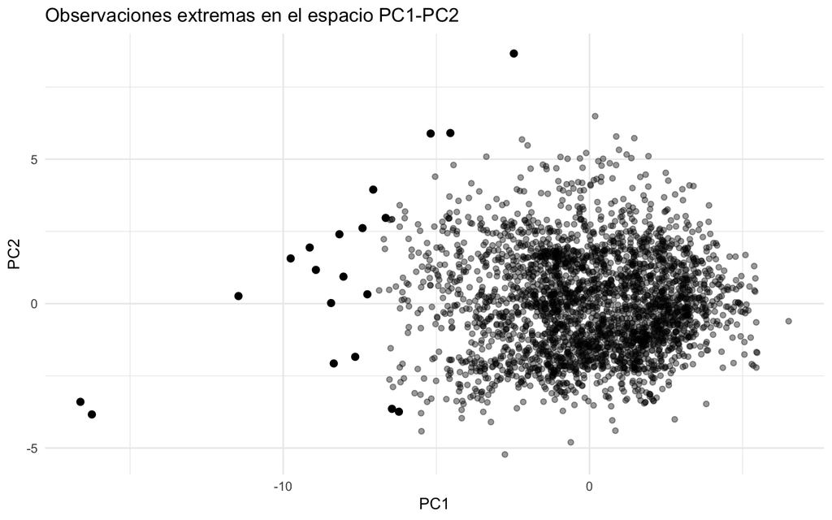

```r
scores_metadata %>%
  ggplot(aes(x = PC1, y = PC2)) +
  geom_point(alpha = 0.4) +
  geom_point(
    data = scores_metadata %>% slice_max(dist_pc12, n = 20),
    aes(x = PC1, y = PC2),
    size = 2
  ) +
  labs(
    title = "Observaciones extremas en el espacio PC1-PC2",
    x = "PC1",
    y = "PC2"
  )
```

## 11.1 Error de reconstrucción

Si retenemos pocos componentes, podemos reconstruir aproximadamente las variables originales. Observaciones con alto error de reconstrucción pueden ser casos raros.

Volver desde los componentes principales hacia una aproximación de los datos originales.

$PC1, PC2, PC3, ... -> datos\_reconstruidos$

Pero si usamos solo algunos componentes, por ejemplo los que explican 80% de la varianza, la reconstrucción no es perfecta. Esa diferencia entre datos originales y datos reconstruidos es el error de reconstrucción.

```r
#vamos a reconstruir los datos usando solo los componentes que explican el 80% de la variabilidad total.
k <- n80
#los scores son las coordenadas de cada casa en los componentes principales.
scores_k <- pca_ames$x[, 1:k]
#Cada fila sigue siendo una casa.
#Cada columna ahora es un componente principal.

#contiene los loadings, es decir, los pesos que dicen cómo cada componente se relaciona con las variables originales.
rotation_k <- pca_ames$rotation[, 1:k]
#dice cómo traducir ese espacio PCA de vuelta a las variables originales.

#Escala los datos originales.
X_scaled <- scale(ames_num_imp)

#Se multiplican los scores por los loadings transpuestos.
# Conceptualmente : datos reconstruidos = scores PCA × loadings
# PCs de cada casa × contribución de variables a cada PC
X_reconstructed <- scores_k %*% t(rotation_k)

#Qué tan mal se reconstruye cada casa usando solo los primeros componentes principales.
reconstruction_error <- rowMeans((X_scaled - X_reconstructed)^2)

outlier_recon <- scores_metadata %>%
  mutate(reconstruction_error = reconstruction_error) %>%
  arrange(desc(reconstruction_error))

outlier_recon %>%
  dplyr::select(reconstruction_error, Sale_Price, Overall_Qual, Gr_Liv_Area, Neighborhood) %>%
  head(10)
```

```
## # A tibble: 10 × 5
##    reconstruction_error Sale_Price Overall_Qual Gr_Liv_Area Neighborhood
##                   <dbl>      <int>        <dbl>       <int> <fct>
##  1                 9.41     375000            7        2036 Timberland
##  2                 5.86     277000            6        2144 Clear_Creek
##  3                 4.82     228950            5        1786 Timberland
##  4                 2.51     302000            7        1824 Clear_Creek
##  5                 2.49     228500            6        1822 Sawyer_West
##  6                 1.98     160000           10        5642 Edwards
##  7                 1.84     284700            5        3820 Edwards
##  8                 1.61     130000            3        2034 Mitchell
##  9                 1.53     151500            6         958 North_Ames
## 10                 1.43     274970            6        2201 Edwards
```

```r
head(outlier_recon)
```

```
## # A tibble: 6 × 44
##      PC1    PC2    PC3   PC4    PC5   PC6    PC7      PC8    PC9   PC10   PC11
##    <dbl>  <dbl>  <dbl> <dbl>  <dbl> <dbl>  <dbl>    <dbl>  <dbl>  <dbl>  <dbl>
## 1  -5.50 -3.79  -10.4  -6.04  2.37   5.66 -0.203  0.946   -1.25   2.43  -0.925
## 2  -4.79  0.198  -5.32 -2.64 -0.921  5.39  2.51  -2.54    -1.78   0.896 -0.627
## 3  -4.15 -3.37   -6.28 -5.86  2.33   5.04  1.65  -0.117   -1.50  -0.477  0.200
## 4  -4.11 -3.48   -3.68 -2.12  0.430  3.44  0.586 -0.00139 -0.773 -0.221  0.181
## 5  -1.36  3.80   -6.28 -1.36 -1.76   9.45 -4.41   4.59     4.03  -3.32   5.23
## 6 -16.6  -3.40  -11.4  -2.61 -0.256  6.94 -3.77   2.16    -0.367 -0.534  1.75
## # ℹ 33 more variables: PC12 <dbl>, PC13 <dbl>, PC14 <dbl>, PC15 <dbl>,
## #   PC16 <dbl>, PC17 <dbl>, PC18 <dbl>, PC19 <dbl>, PC20 <dbl>, PC21 <dbl>,
## #   PC22 <dbl>, PC23 <dbl>, PC24 <dbl>, PC25 <dbl>, PC26 <dbl>, PC27 <dbl>,
## #   PC28 <dbl>, PC29 <dbl>, PC30 <dbl>, PC31 <dbl>, PC32 <dbl>, PC33 <dbl>,
## #   PC34 <dbl>, Sale_Price <int>, log_Sale_Price <dbl>, Overall_Qual <dbl>,
## #   Year_Built <int>, Gr_Liv_Area <int>, Total_Bsmt_SF <dbl>,
## #   Garage_Area <dbl>, Neighborhood <fct>, dist_pc12 <dbl>, …
```

```r
dim(outlier_recon)
```

```
## [1] 2930   44
```

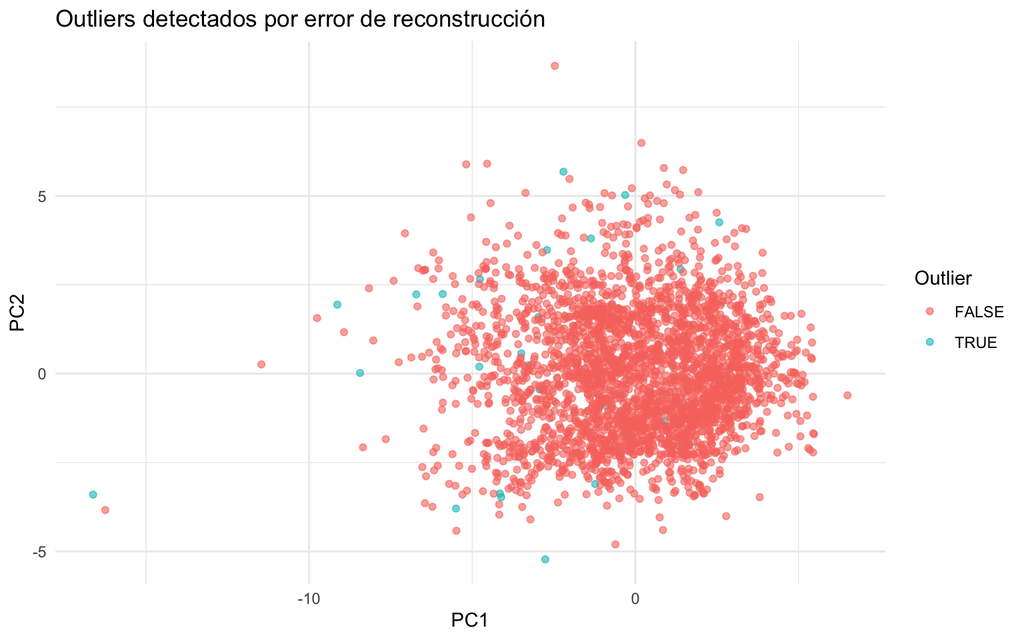

```r
threshold <- quantile(outlier_recon$reconstruction_error, 0.99)

outlier_recon %>%
  mutate(is_outlier = reconstruction_error >= threshold) %>%
  ggplot(aes(x = PC1, y = PC2, color = is_outlier)) +
  geom_point(alpha = 0.6) +
  labs(
    title = "Outliers detectados por error de reconstrucción",
    x = "PC1",
    y = "PC2",
    color = "Outlier"
  )
```

¿Qué significa un alto error de reconstrucción?

Una casa con alto error de reconstrucción puede ser rara porque tiene una combinación inusual, por ejemplo:

- casa muy grande pero precio bajo;
- casa pequeña pero precio muy alto;
- casa antigua pero con alta calidad;
- casa en barrio caro pero con baja calidad;
- casa con gran superficie pero sin garaje;
- combinación rara de sótano, superficie, calidad y año de construcción.

No necesariamente es un error. Puede ser:

- Un outlier real.
- Un caso interesante.
- Un dato mal registrado.
- Una propiedad atípica.
- Una combinación minoritaria no capturada por los primeros PCs.